# R tutorial

Sebastian Kopf

2018-05-13

**R markdown** is a version of Markdown that is expanded to support running R code in between your text. The blocks of R code are called `chunks` and you can treat them as individual little segments of code, you can jump back and forth between them, run just individual ones or run all of them when you click the **Knit** button - this will generate a document that includes both content as well as the output of any embedded R code chunks within the document. This is an R code chunk:

## Assigning values

```r
# the <- operator assigns the variable on the pointy side of the arrow the value on the other side
data <- faithful # assign the built-in faithful data set to the data variable

# use ? to get help about functions and data sets
?faithful

# output what is in the data variable
data
```

|  | eruptions | waiting |
| --- | --- | --- |
| 1 | 3.600 | 79 |
| 2 | 1.800 | 54 |
| 3 | 3.333 | 74 |
| 4 | 2.283 | 62 |
| 5 | 4.533 | 85 |
| 6 | 2.883 | 55 |
| 7 | 4.700 | 88 |
| 8 | 3.600 | 85 |
| 9 | 1.950 | 51 |
| 10 | 4.350 | 85 |

[output cut: 262 more lines]

#### Excercise

```r
# assign the variable x a value of 5 and print the value of x
```

## The pipe operator

The pipe operator `%>%` is a a very useful alternative to passing arguments between functions. It is ideal for chaining together multiple commands.

```r
# R libraries provide additional functionality not included in the core and can be loaded as the functionality becomes needed
library(magrittr) # load the magrittr library to include the pipe operator

# the following is equivalent
summary(data) # same syntax as used above
```

```
##    eruptions        waiting
##  Min.   :1.600   Min.   :43.0
##  1st Qu.:2.163   1st Qu.:58.0
##  Median :4.000   Median :76.0
##  Mean   :3.488   Mean   :70.9
##  3rd Qu.:4.454   3rd Qu.:82.0
##  Max.   :5.100   Max.   :96.0
```

```r
data %>% summary() # pipe syntax
```

```
##    eruptions        waiting
##  Min.   :1.600   Min.   :43.0
##  1st Qu.:2.163   1st Qu.:58.0
##  Median :4.000   Median :76.0
##  Mean   :3.488   Mean   :70.9
##  3rd Qu.:4.454   3rd Qu.:82.0
##  Max.   :5.100   Max.   :96.0
```

```r
# the advantage of the pipe is easy changing, here we use the head function (?head for help) to get the first couple of data points in our data set and then calculate the square root
sqrt(head(data))
```

|  | eruptions | waiting |
| --- | --- | --- |
| 1 | 1.897367 | 8.888194 |
| 2 | 1.341641 | 7.348469 |
| 3 | 1.825651 | 8.602325 |
| 4 | 1.510960 | 7.874008 |
| 5 | 2.129084 | 9.219544 |
| 6 | 1.697940 | 7.416198 |

```r
# instead of the infintie russian doll of (((()))) as operations become more complicated, the pipe makes this much easier to read
# the follwing is EQUIVALENT to the above:
data %>% head() %>% sqrt()
```

|  | eruptions | waiting |
| --- | --- | --- |
| 1 | 1.897367 | 8.888194 |
| 2 | 1.341641 | 7.348469 |
| 3 | 1.825651 | 8.602325 |
| 4 | 1.510960 | 7.874008 |
| 5 | 2.129084 | 9.219544 |
| 6 | 1.697940 | 7.416198 |

```r
# or spaced out over multiple rows
data %>% # pipe the data to the head function
  # returns the first couple of rows of the data set and pipes them onward
  head() %>%
  # sqrt function receives the output from the head function via the pipe and prints it
  sqrt()
```

|  | eruptions | waiting |
| --- | --- | --- |
| 1 | 1.897367 | 8.888194 |
| 2 | 1.341641 | 7.348469 |
| 3 | 1.825651 | 8.602325 |
| 4 | 1.510960 | 7.874008 |
| 5 | 2.129084 | 9.219544 |
| 6 | 1.697940 | 7.416198 |

#### Exercise

```r
# the runif function returns random numbers from a uniform distribution
# use the pipe to pass your value of x to the runif function

# repeat the same but now pipe it onward to the summary function
```

```r
# now assign a new value of 10000 to the x function and rerun your command
```

## Text output

You can also output the value of a variable within your text, say the value of $\pi$ with 4 significant digits: 3.142 or the number of data points in your data set: 272.

## Standard plots

And of course you can embed plots, for example:

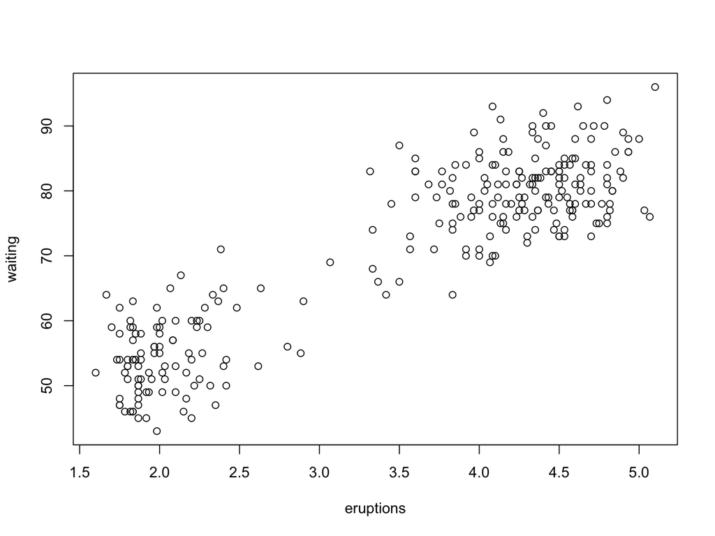

Notice that the chunk options `fig.width` and `fig.height` are providing additional details on how the plot in the chunk should be displayed in the knitted report. The option `echo=FALSE` indicates that the code chunk itself should not be displayed in the final report. We will make more complex plots later, but that’s it for now.

## Additional

For additional information on R and R markdown, there are lots of great resources on the internet and the R user community is very active and extremely helpful. Often, googling what you’d like to achieve will provide a good starting point but I can also recommend the following resources specifically:

- [different R cheatsheets](https://www.rstudio.com/resources/cheatsheets/)
- [older R reference manual](http://cran.r-project.org/doc/contrib/Short-refcard.pdf) (a great overview of many useful R commands)
- [R coding overview compiled by Sebastian](https://paper.dropbox.com/doc/Getting-started-with-R-BJ4pKzfZhBYxfdB6RowE0)
- [R for Data Science online book](http://r4ds.had.co.nz/)
- [RMarkdown code chunk options](http://yihui.name/knitr/options/)
- [Stack Overflow](http://stackoverflow.com/) (a Q&A site for programming, searching for answers here often provides very helpful information)